Saltar al contenido principal

# Análisis Predictivo en Business Intelligence: regresión en R

Autor/a

Fernando Salcedo Mejía Eco, Ms

Fecha de publicación

1 de febrero de 2026

Este notebook desarrolla en R el caso de estudio de regresión de la presentación **Análisis Predictivo en Business Intelligence**. El modelo se estima con la función `lm()` de R base y los datos se manipulan con el [**tidyverse**](https://www.tidyverse.org/).

Las funciones de R base que se usan con un modelo estimado con `lm()` son:

| Función | Para qué sirve |
| --- | --- |
| `lm()` | Estimar la regresión lineal por mínimos cuadrados |
| `summary()` | Ver coeficientes, errores estándar, valores p y $R^2$ |
| `coef()`, `confint()` | Extraer los coeficientes y sus intervalos de confianza |
| `predict()` | Pronosticar la respuesta para datos nuevos |

```r
library(tidyverse)

theme_set(theme_minimal(base_size = 13))
```

# 1 Estimación y pronóstico de la demanda

La gerencia de una tienda de electrónica quiere ajustar los precios de sus cinco productos estrella para el próximo trimestre. Para anticipar el efecto en las ventas se estima la **elasticidad precio de la demanda** de cada producto con un modelo log-log:

$$\ln(Q) = \beta_1 + \beta_2 \ln(P) + \varepsilon, \qquad E_p = \beta_2$$

## 1.1 Datos

Ventas mensuales de cada producto entre 2016 y 2023.

```r
ventas <- read_csv("datos/ventas_electronica.csv", show_col_types = FALSE)
head(ventas)
```

| producto | fecha | precio | cantidad |
| --- | --- | --- | --- |
| Audífonos | 2016-01-01 | 85.16 | 4768 |
| Audífonos | 2016-02-01 | 70.28 | 8011 |
| Audífonos | 2016-03-01 | 81.35 | 4688 |
| Audífonos | 2016-04-01 | 79.19 | 4429 |
| Audífonos | 2016-05-01 | 73.85 | 7937 |
| Audífonos | 2016-06-01 | 59.15 | 12892 |

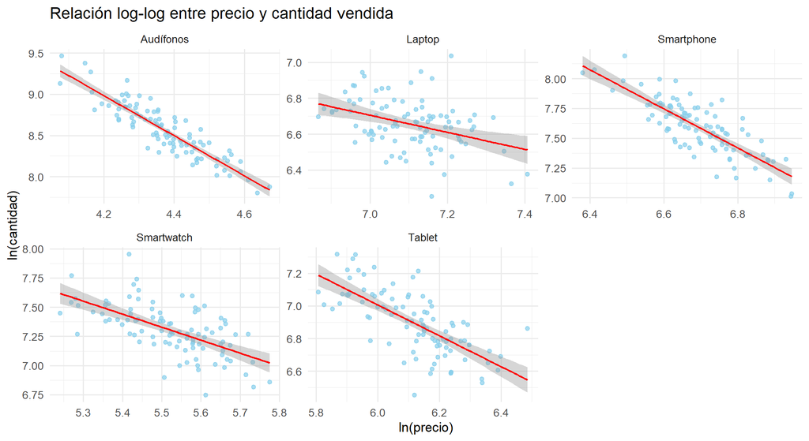

```r
ggplot(ventas, aes(log(precio), log(cantidad))) +
  geom_point(color = "skyblue", alpha = 0.7) +
  geom_smooth(method = "lm", color = "red", linewidth = 0.8) +
  facet_wrap(~producto, scales = "free") +
  labs(
    title = "Relación log-log entre precio y cantidad vendida",
    x = "ln(precio)",
    y = "ln(cantidad)"
  )
```

## 1.2 Estimación de la elasticidad

Se estima una regresión con `lm()` por producto. El coeficiente de $\ln(P)$ es la elasticidad. Un ciclo `for()` recorre los productos y en cada vuelta:

1. Filtra las ventas del producto.
2. Estima el modelo log-log con `lm()` y lo guarda en la lista `ajustes_demanda`.
3. Extrae la elasticidad, su intervalo de confianza, el valor p y el $R^2$, y los agrega como una fila a la tabla `elasticidades`.

```r
productos <- sort(unique(ventas$producto))

ajustes_demanda <- list() # aquí se guarda el modelo de cada producto
elasticidades <- tibble() # aquí se acumula una fila por producto

for (p in productos) {
  # 1. Datos del producto
  datos_p <- filter(ventas, producto == p)

  # 2. Estimar el modelo log-log
  modelo <- lm(log(cantidad) ~ log(precio), data = datos_p)
  ajustes_demanda[[p]] <- modelo

  # 3. Extraer los resultados del coeficiente de log(precio)
  ic <- confint(modelo)["log(precio)", ]
  resumen <- summary(modelo)

  resultado <- tibble(
    producto = p,
    elasticidad = coef(modelo)[["log(precio)"]],
    conf.low = ic[[1]],
    conf.high = ic[[2]],
    p.value = resumen$coefficients["log(precio)", "Pr(>|t|)"],
    r2 = resumen$r.squared
  )
  elasticidades <- bind_rows(elasticidades, resultado)
}

elasticidades
```

| producto | elasticidad | conf.low | conf.high | p.value | r2 |
| --- | --- | --- | --- | --- | --- |
| Audífonos | -2.4322026 | -2.6749476 | -2.1894577 | 0.0000000 | 0.8080754 |
| Laptop | -0.4766162 | -0.7152905 | -0.2379420 | 0.0001431 | 0.1432806 |
| Smartphone | -1.6427821 | -1.8897495 | -1.3958147 | 0.0000000 | 0.6498206 |
| Smartwatch | -1.1124006 | -1.4033274 | -0.8214737 | 0.0000000 | 0.3801005 |
| Tablet | -0.9460205 | -1.1423211 | -0.7497199 | 0.0000000 | 0.4934264 |

Este es el resultado completo de `summary()` para uno de los modelos guardados:

```r
summary(ajustes_demanda[["Audífonos"]])
```

```
Call:
lm(formula = log(cantidad) ~ log(precio), data = datos_p)

Residuals:
     Min       1Q   Median       3Q      Max
-0.33592 -0.11239  0.00354  0.09990  0.34489

Coefficients:
            Estimate Std. Error t value Pr(>|t|)
(Intercept)  19.1992     0.5348   35.90   <2e-16 ***
log(precio)  -2.4322     0.1223  -19.89   <2e-16 ***
---
Signif. codes:  0 '***' 0.001 '**' 0.01 '*' 0.05 '.' 0.1 ' ' 1

Residual standard error: 0.1449 on 94 degrees of freedom
Multiple R-squared:  0.8081,    Adjusted R-squared:  0.806
F-statistic: 395.8 on 1 and 94 DF,  p-value: < 2.2e-16
```

Todas las elasticidades son negativas y significativas, como predice la **ley de la demanda**. Por ejemplo, para los audífonos un aumento del 1 % en el precio reduce la cantidad vendida en cerca de 2.4 %.

## 1.3 Usar el modelo para la toma de decisión de precios

La pregunta de la gerencia es: **si cambio el precio, ¿qué pasa con el ingreso?** Como el modelo está en logaritmos, todo se puede razonar con **tasas de cambio** (cambios porcentuales), que se suman y se multiplican de forma lineal.

**Paso 1. La elasticidad convierte la tasa del precio en tasa de la cantidad.** En el modelo log-log, un cambio en $\ln(P)$ produce un cambio $E_p$ veces mayor en $\ln(Q)$. Como el cambio en el logaritmo es aproximadamente la tasa de cambio:

$$\%\Delta Q \approx E_p \cdot \%\Delta P$$

**Paso 2. La tasa del ingreso es la suma de las tasas del precio y de la cantidad.** El ingreso es $I = P \cdot Q$; al tomar logaritmos el producto se vuelve una suma, $\ln(I) = \ln(P) + \ln(Q)$, y por tanto:

$$\%\Delta I \approx \%\Delta P + \%\Delta Q$$

**Paso 3. Reemplazar el paso 1 en el paso 2.**

$$\%\Delta I \approx \%\Delta P + E_p \cdot \%\Delta P = (1 + E_p) \cdot \%\Delta P$$

El ingreso cambia en proporción al cambio del precio, y el término $(1 + E_p)$ dice en qué dirección:

| Tipo de demanda | Elasticidad | $1 + E_p$ | Si el precio sube | Decisión |
| --- | --- | --- | --- | --- |
| **Elástica** | $E_p < -1$ | negativo | la cantidad cae más que lo que sube el precio: el ingreso **baja** | Bajar el precio |
| **Inelástica** | $-1 < E_p < 0$ | positivo | la cantidad cae menos que lo que sube el precio: el ingreso **sube** | Subir el precio |

La aproximación es buena para cambios pequeños de precio (alrededor de ±10 %). Para cambios grandes conviene calcular el ingreso con `predict()`, como en la sección siguiente.

### 1.3.1 Ejemplo con los audífonos

Se aplican los tres pasos con la elasticidad estimada de los audífonos para una subida de precio del 5 %:

```r
e_aud <- elasticidades$elasticidad[elasticidades$producto == "Audífonos"]
cambio_precio <- 5 # el precio sube 5 %

cambio_cantidad <- e_aud * cambio_precio         # paso 1
cambio_ingreso <- cambio_precio + cambio_cantidad # pasos 2 y 3

tibble(
  elasticidad = e_aud,
  `%Δ precio` = cambio_precio,
  `%Δ cantidad` = cambio_cantidad,
  `%Δ ingreso` = cambio_ingreso
) |>
  round(2)
```

| elasticidad | %Δ precio | %Δ cantidad | %Δ ingreso |
| --- | --- | --- | --- |
| -2.43 | 5 | -12.16 | -7.16 |

El precio sube 5 % y la cantidad cae cerca de 12.2 %, así que el ingreso cambia -7.2 %: la demanda de los audífonos es elástica y conviene **bajar** el precio.

### 1.3.2 Todos los productos

Se escribe el paso 3 como una función y se aplica a cada producto:

```r
cambio_ingreso <- function(cambio_precio, elasticidad) {
  (1 + elasticidad) * cambio_precio
}

elasticidades |>
  transmute(
    producto,
    elasticidad = round(elasticidad, 2),
    tipo = if_else(elasticidad < -1, "Elástica", "Inelástica"),
    `%Δ ingreso si el precio sube 5 %` = round(cambio_ingreso(5, elasticidad), 1),
    `%Δ ingreso si el precio baja 5 %` = round(cambio_ingreso(-5, elasticidad), 1),
    recomendacion = if_else(elasticidad < -1, "Bajar precio", "Subir precio")
  )
```

| producto | elasticidad | tipo | %Δ ingreso si el precio sube 5 % | %Δ ingreso si el precio baja 5 % | recomendacion |
| --- | --- | --- | --- | --- | --- |
| Audífonos | -2.43 | Elástica | -7.2 | 7.2 | Bajar precio |
| Laptop | -0.48 | Inelástica | 2.6 | -2.6 | Subir precio |
| Smartphone | -1.64 | Elástica | -3.2 | 3.2 | Bajar precio |
| Smartwatch | -1.11 | Elástica | -0.6 | 0.6 | Bajar precio |
| Tablet | -0.95 | Inelástica | 0.3 | -0.3 | Subir precio |

Antes de decidir conviene mirar los intervalos de confianza: para Smartwatch y Tablet el intervalo incluye $E_p = -1$, por lo que no se puede afirmar si la demanda es elástica o inelástica y el efecto de un cambio de precio sobre el ingreso es pequeño e incierto.

## 1.4 Pronóstico con el modelo

Con `predict()` se pronostica la cantidad para un precio nuevo. Por ejemplo, el efecto de bajar 5 % el precio de los audífonos respecto a su precio promedio:

```r
ajuste_audifonos <- ajustes_demanda[["Audífonos"]]

precio_medio <- mean(ventas$precio[ventas$producto == "Audífonos"])

escenarios <- tibble(
  escenario = c("Precio promedio", "Precio -5 %"),
  precio = precio_medio * c(1, 0.95)
)

escenarios |>
  mutate(
    cantidad = exp(predict(ajuste_audifonos, newdata = escenarios)),
    ingreso = precio * cantidad,
    across(where(is.numeric), \(x) round(x, 1))
  )
```

| escenario | precio | cantidad | ingreso |
| --- | --- | --- | --- |
| Precio promedio | 79.8 | 5149.6 | 411047.1 |
| Precio -5 % | 75.8 | 5833.8 | 442380.5 |